# Assignment

Berj Dekramanjian

2022-10-19

## Practical Machine Learning Assignment

The goal of this markdown will be to use data from accelerators on the belt, forearm, arm, and dumbbell of 6 participants to predict the manner in which they did the exercise. The report describes how the model was built, how it was cross validated, and why you different choices were made.

```r
library(rpart)
library(rpart.plot)
library(lattice)
library(ggplot2)
library(corrplot)
library(randomForest)
library(rattle)
library(tidyverse)
library(caret)
```

Nine different packages are loaded

```r
data_train <- read.csv("pml-training.csv")[,-1]
data_quiz <- read.csv("pml-testing.csv")[,-1]
dim(data_train)
```

```
## [1] 19622   159
```

```r
dim(data_quiz)
```

```
## [1]  20 159
```

Both sets of data were loaded, and the dimensions of the training and testing data checked.

```r
NZV <- nearZeroVar(data_train)
data_train <- data_train[, -NZV]
data_quiz <- data_quiz[, -NZV]

NaValues <- sapply(data_train, function(x) mean(is.na(x))) > 0.9
data_train <- data_train[, NaValues == "FALSE"]
data_quiz <- data_quiz[, NaValues == "FALSE"]

data_train <- data_train[,-c(1:5)]
data_quiz <- data_quiz[,-c(1:5)]

dim(data_train)
```

```
## [1] 19622    53
```

```r
dim(data_quiz)
```

```
## [1] 20 53
```

```r
in_train  <- createDataPartition(data_train$classe, p=0.75, list=FALSE)
train_set <- data_train[ in_train, ]
test_set  <- data_train[-in_train, ]

dim(train_set)
```

```
## [1] 14718    53
```

```r
dim(test_set)
```

```
## [1] 4904   53
```

test data was partitioned for further analysis

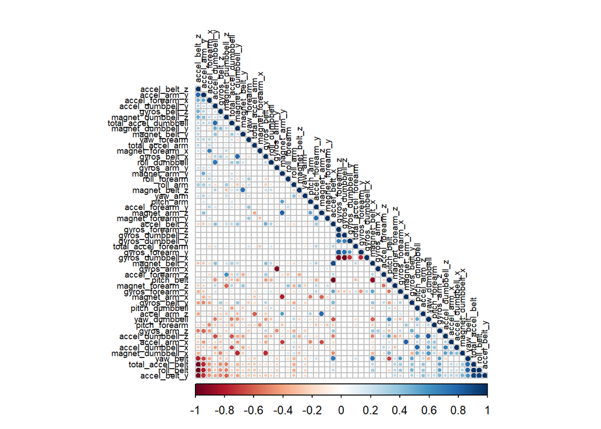

```r
corr_matrix <- cor(train_set[ ,-53])
corrplot(corr_matrix, order = "FPC", method = "circle", type = "lower",
         tl.cex = 0.6, tl.col = rgb(0, 0, 0))
```

Since there aren’t that many variables that are correlated, it seems multiple prediction models might be needed. first off with a decision tree.

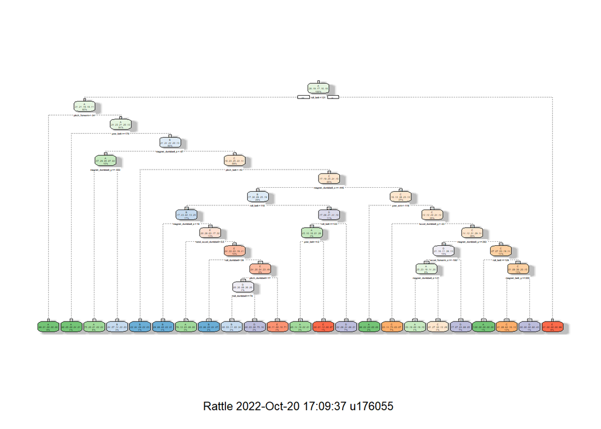

```r
fit_decision_tree <- rpart(classe ~ ., data = train_set, method="class")
fancyRpartPlot(fit_decision_tree)
```

```r
predict_decision_tree <- predict(fit_decision_tree, newdata = test_set, type="class")
conf_matrix_decision_tree <- confusionMatrix(predict_decision_tree, factor(test_set$classe))
conf_matrix_decision_tree
```

```
## Confusion Matrix and Statistics
##
##           Reference
## Prediction    A    B    C    D    E
##          A 1281  151   41   68   31
##          B   25  575   62   55   46
##          C   18  148  651  140  156
##          D   57   55   91  514   60
##          E   14   20   10   27  608
##
## Overall Statistics
##
##                Accuracy : 0.74
##                  95% CI : (0.7275, 0.7522)
##     No Information Rate : 0.2845
##     P-Value [Acc > NIR] : < 2.2e-16
##
##                   Kappa : 0.6699
##
##  Mcnemar's Test P-Value : < 2.2e-16
##
## Statistics by Class:
##
##                      Class: A Class: B Class: C Class: D Class: E
## Sensitivity            0.9183   0.6059   0.7614   0.6393   0.6748
## Specificity            0.9171   0.9525   0.8859   0.9359   0.9823
## Pos Pred Value         0.8149   0.7536   0.5849   0.6615   0.8954
## Neg Pred Value         0.9658   0.9097   0.9462   0.9297   0.9307
## Prevalence             0.2845   0.1935   0.1743   0.1639   0.1837
## Detection Rate         0.2612   0.1173   0.1327   0.1048   0.1240
## Detection Prevalence   0.3206   0.1556   0.2270   0.1584   0.1385
## Balanced Accuracy      0.9177   0.7792   0.8237   0.7876   0.8285
```

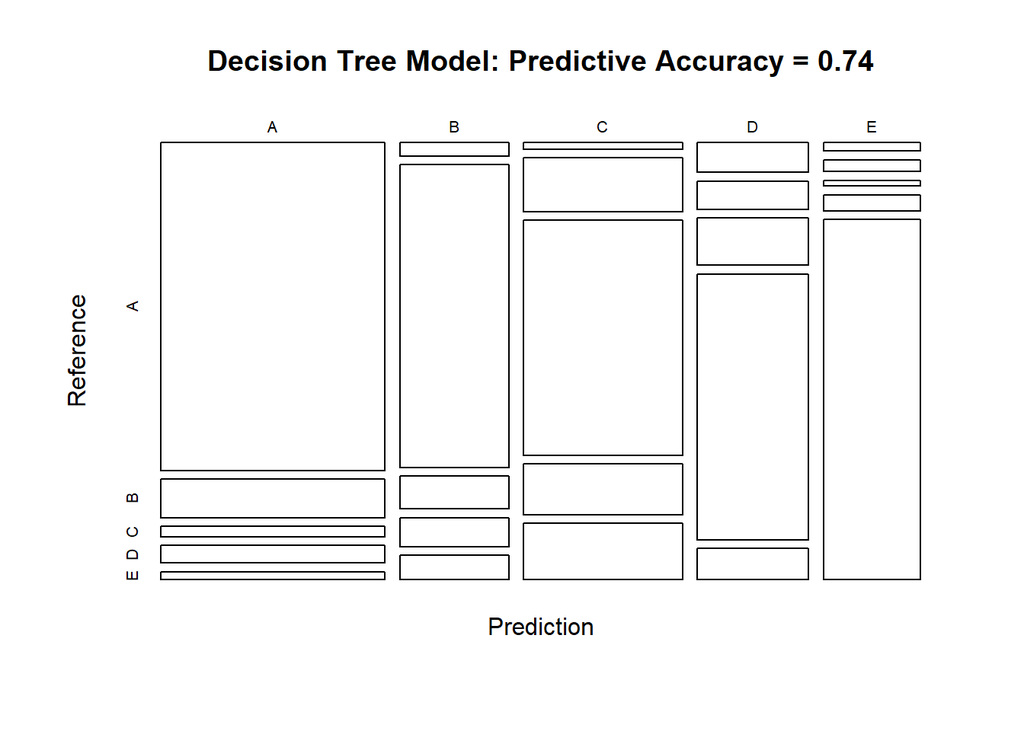

```r
plot(conf_matrix_decision_tree$table, col = conf_matrix_decision_tree$byClass,
     main = paste("Decision Tree Model: Predictive Accuracy =",
                  round(conf_matrix_decision_tree$overall['Accuracy'], 4)))
```

```r
ctrl_GBM <- trainControl(method = "repeatedcv", number = 5, repeats = 2)
fit_GBM  <- train(classe ~ ., data = train_set, method = "gbm",
                  trControl = ctrl_GBM, verbose = FALSE)
fit_GBM$finalModel
```

```
## A gradient boosted model with multinomial loss function.
## 150 iterations were performed.
## There were 52 predictors of which 52 had non-zero influence.
```

```r
predict_GBM <- predict(fit_GBM, newdata = test_set)
conf_matrix_GBM <- confusionMatrix(predict_GBM, factor(test_set$classe))
conf_matrix_GBM
```

```
## Confusion Matrix and Statistics
##
##           Reference
## Prediction    A    B    C    D    E
##          A 1374   33    0    0    1
##          B   15  889   28    6    4
##          C    2   26  813   28    4
##          D    4    1   10  764   17
##          E    0    0    4    6  875
##
## Overall Statistics
##
##                Accuracy : 0.9615
##                  95% CI : (0.9557, 0.9667)
##     No Information Rate : 0.2845
##     P-Value [Acc > NIR] : < 2.2e-16
##
##                   Kappa : 0.9512
##
##  Mcnemar's Test P-Value : 0.0001162
##
## Statistics by Class:
##
##                      Class: A Class: B Class: C Class: D Class: E
## Sensitivity            0.9849   0.9368   0.9509   0.9502   0.9711
## Specificity            0.9903   0.9866   0.9852   0.9922   0.9975
## Pos Pred Value         0.9759   0.9437   0.9313   0.9598   0.9887
## Neg Pred Value         0.9940   0.9849   0.9896   0.9903   0.9935
## Prevalence             0.2845   0.1935   0.1743   0.1639   0.1837
## Detection Rate         0.2802   0.1813   0.1658   0.1558   0.1784
## Detection Prevalence   0.2871   0.1921   0.1780   0.1623   0.1805
## Balanced Accuracy      0.9876   0.9617   0.9680   0.9712   0.9843
```

Lastly we do a random forest model

```r
ctrl_RF <- trainControl(method = "repeatedcv", number = 5, repeats = 2)
fit_RF  <- train(classe ~ ., data = train_set, method = "rf",
                  trControl = ctrl_RF, verbose = FALSE)
fit_RF$finalModel
```

```
##
## Call:
##  randomForest(x = x, y = y, mtry = param$mtry, verbose = FALSE)
##                Type of random forest: classification
##                      Number of trees: 500
## No. of variables tried at each split: 27
##
##         OOB estimate of  error rate: 0.58%
## Confusion matrix:
##      A    B    C    D    E class.error
## A 4180    2    2    0    1 0.001194743
## B   17 2825    6    0    0 0.008075843
## C    0   10 2550    7    0 0.006622517
## D    0    0   26 2384    2 0.011608624
## E    0    0    5    8 2693 0.004804139
```

```r
predict_RF <- predict(fit_RF, newdata = test_set)
conf_matrix_RF <- confusionMatrix(predict_RF, factor(test_set$classe))
conf_matrix_RF
```

```
## Confusion Matrix and Statistics
##
##           Reference
## Prediction    A    B    C    D    E
##          A 1393    8    0    0    0
##          B    2  940    7    1    1
##          C    0    1  847    9    1
##          D    0    0    1  794    4
##          E    0    0    0    0  895
##
## Overall Statistics
##
##                Accuracy : 0.9929
##                  95% CI : (0.9901, 0.995)
##     No Information Rate : 0.2845
##     P-Value [Acc > NIR] : < 2.2e-16
##
##                   Kappa : 0.991
##
##  Mcnemar's Test P-Value : NA
##
## Statistics by Class:
##
##                      Class: A Class: B Class: C Class: D Class: E
## Sensitivity            0.9986   0.9905   0.9906   0.9876   0.9933
## Specificity            0.9977   0.9972   0.9973   0.9988   1.0000
## Pos Pred Value         0.9943   0.9884   0.9872   0.9937   1.0000
## Neg Pred Value         0.9994   0.9977   0.9980   0.9976   0.9985
## Prevalence             0.2845   0.1935   0.1743   0.1639   0.1837
## Detection Rate         0.2841   0.1917   0.1727   0.1619   0.1825
## Detection Prevalence   0.2857   0.1939   0.1750   0.1629   0.1825
## Balanced Accuracy      0.9981   0.9939   0.9940   0.9932   0.9967
```

we are going to go ahead and use the random forest model for our predicitons for the quiz.

```r
predict_quiz <- as.data.frame(predict(fit_RF, newdata = data_quiz))
predict_quiz
```

```
##    predict(fit_RF, newdata = data_quiz)
## 1                                     B
## 2                                     A
## 3                                     B
## 4                                     A
## 5                                     A
## 6                                     E
## 7                                     D
## 8                                     B
## 9                                     A
## 10                                    A
## 11                                    B
## 12                                    C
## 13                                    B
## 14                                    A
## 15                                    E
## 16                                    E
## 17                                    A
## 18                                    B
## 19                                    B
## 20                                    B
```